# Week 6 Slides

## High Throughput Sequencing

## High Throughput Sequencing

- High throughput sequencing (HTS) technologies measure and digitize the nucleotide sequences of thousands to billions of DNA molecules simultaneously
- HTS instruments can determine sequence of any DNA molecule in a sample
- HTS datasets sometimes called *unbiased* assays
- Most popular HTS technology today is provided by [Illumina biotechnology company](https://en.wikipedia.org/wiki/Illumina,_Inc.)

## Sequencing by synthesis

- Illumina sequencing uses biotechnological technique called *sequencing by synthesis*
- Sequencing instruments are called *sequencers*
- The process, briefly:
  1. \(10^7\) to \(10^9\) short (~300 nucleotide long) DNA molecules ligated to glass slide
  2. Denatured to become single stranded,
  3. Complementary strand by incorporating fluorescently tagged nucleotides
  4. Tagged nucleotides excited by a laser and photograph taken of slide
  5. Images are processed to reconstruct DNA sequences from fluorescence events

## HTS Measures DNA

- Any DNA molecules may be subjected to sequencing via this method
- Many different types of experiments are possible:
  - *Whole genome sequencing (WGS)*
  - *RNA Sequencing (RNASeq)*
  - *Whole genome bisulfite sequencing (WGBS)*
  - *Chromatin immunoprecipitation followed by sequencing (ChIPSeq)*
- Each of these experiments create the same type of data
- Each must be interpreted appropriately based on experiment

## Raw HTS Data

- Raw HTS data are the digitized DNA sequences for the billions of molecules captured by the flow cell
- Each digitized nucleotide sequence is called a *read*
- Data stored in a standardized format called the [FASTQ file format](https://en.wikipedia.org/wiki/FASTQ_format)

## FASTQ Format

- Data for a single read in FASTQ format:

```
@SEQ_ID
GATTTGGGGTTCAAAGCAGTATCGATCAAATAGTAAATCCATTTGTTCAACTCACAGTTT
+
!''*((((***+))%%%++)(%%%%).1***-+*''))**55CCF>>>>>>CCCCCCC65
```

- `@` - header, unique read name per flowcell
- `GAT...` - the nucleotide sequence
- `+` - second header, usually blank
- `!''...` - the [phred quality scores](https://en.wikipedia.org/wiki/Phred_quality_score) for each base in the read

## HTS Sequence Analysis

- Raw sequencing reads must be processed with bioinformatic algorithms
- Two broad classes of sequence analysis:
  - *de novo* assembly to recover complete length of original molecules
  - *sequence alignment* against a set of reference sequences, e.g. genome
- Most data we analyze in R comes from aligned reads that have been produced by other software

## Sequence Alignment

- Reads aligned to a reference sequence form a distribution of read counts across all locations in the reference sequence
- Any given reference sequence location, or *locus*, has zero or more reads that align to it
- The number of reads aligning to a given locus is called the *read count*
- The read count is proportional to the copy number of molecules in the sample that correspond to that locus
- Read counts from all genes in a reference genome form *count data*

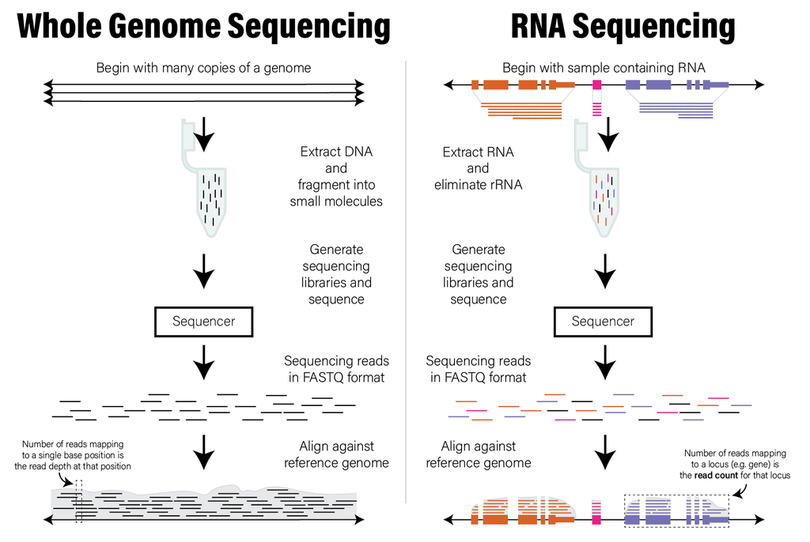

## Count Data

- The *read counts* that align to each locus of a genome form a distribution
- Count data have two important properties:
  - **Count data are integers**
  - **Counts are non-negative**
- *count data are not normally distributed*

## RNASeq

- RNA sequencing (RNASeq) digitizes the RNA molecules in a sample
- Short reads (~100-300 nucleotides long) represent RNA fragments from longer transcripts
- RNA molecules are (in principle) sequenced in proportion to their relative copy number in the original sample
- Each sequencing dataset has a total number of reads called *library size*
- Relative copy number means *absence of evidence is not evidence of absence*
  - i.e. count of zero does *not necessarily mean* no molecules

## RNASeq Gene Expression Data

- When aligned, reads are counted using a *reference annotation* that defines locations of genes in the genome
- For a single sample, output is a vector of read counts for each gene in the annotation
- Genes with no reads mapping to them will have a count of zero
- All others will have a read count of one or more;
- Complex multicellular organisms have on the order of thousands to tens of thousands of genes

## The Counts Matrix

- Read counts from multiple samples of genes using the same annotation are usually concatenated into a *counts matrix*
- Counts matrix usually has genes as rows and samples as columns (not tidy!)
- Usually in `csv` or `tsv` (tab separated) format
- These counts are from O’Meara et al 2014

```r
counts <- read_tsv("verse_counts.tsv")
```

## Example Counts Matrix

```r
counts
```

```
## # A tibble: 55,416 × 9
##    gene                  P0_1  P0_2  P4_1  P4_2  P7_1  P7_2  Ad_1  Ad_2
##    <chr>                <dbl> <dbl> <dbl> <dbl> <dbl> <dbl> <dbl> <dbl>
##  1 ENSMUSG00000102693.2     0     0     0     0     0     0     0     0
##  2 ENSMUSG00000064842.3     0     0     0     0     0     0     0     0
##  3 ENSMUSG00000051951.6    19    24    17    17    17    12     7     5
##  4 ENSMUSG00000102851.2     0     0     0     0     1     0     0     0
##  5 ENSMUSG00000103377.2     1     0     0     1     0     1     1     0
##  6 ENSMUSG00000104017.2     0     3     0     0     0     1     0     0
##  7 ENSMUSG00000103025.2     0     0     0     0     0     0     0     0
##  8 ENSMUSG00000089699.2     0     0     0     0     0     0     0     0
##  9 ENSMUSG00000103201.2     0     0     0     0     0     0     0     1
## 10 ENSMUSG00000103147.2     0     0     0     0     0     0     0     0
## # ℹ 55,406 more rows
```

## Analyzing Counts Data

There are typically three steps when analyzing a RNASeq count matrix:

1. **Filter genes that are unlikely to be differentially expressed.**
2. **Normalize filtered counts to make samples comparable to one another.**
3. **Differential expression analysis of filtered, normalized counts.**

## Filtering Counts

- Genes not detected in any sample (counts are zero) should not be considered
- Genes with very low counts are not likely to be informative
- Eliminating these genes from consideration reduce multiple hypothesis testing burden later
- General approach: set read count criteria to filter out genes

## Filtering Undetected Genes

- Genes not detected in any sample should be filtered

```r
nonzero_genes <- rowSums(counts[-1])!=0
filtered_counts <- counts[nonzero_genes,]
slice_head(filtered_counts, n=5)
```

```
## # A tibble: 5 × 9
##   gene                  P0_1  P0_2  P4_1  P4_2  P7_1  P7_2  Ad_1  Ad_2
##   <chr>                <dbl> <dbl> <dbl> <dbl> <dbl> <dbl> <dbl> <dbl>
## 1 ENSMUSG00000051951.6    19    24    17    17    17    12     7     5
## 2 ENSMUSG00000102851.2     0     0     0     0     1     0     0     0
## 3 ENSMUSG00000103377.2     1     0     0     1     0     1     1     0
## 4 ENSMUSG00000104017.2     0     3     0     0     0     1     0     0
## 5 ENSMUSG00000103201.2     0     0     0     0     0     0     0     1
```

## Filtering Very Low Count Genes

- Genes with fewer than 2 reads across all samples filtered

```r
nonzero_genes <- rowSums(counts[-1])>=2
filtered_counts <- counts[nonzero_genes,]
slice_head(filtered_counts, n=5)
```

```
## # A tibble: 5 × 9
##   gene                   P0_1  P0_2  P4_1  P4_2  P7_1  P7_2  Ad_1  Ad_2
##   <chr>                 <dbl> <dbl> <dbl> <dbl> <dbl> <dbl> <dbl> <dbl>
## 1 ENSMUSG00000051951.6     19    24    17    17    17    12     7     5
## 2 ENSMUSG00000103377.2      1     0     0     1     0     1     1     0
## 3 ENSMUSG00000104017.2      0     3     0     0     0     1     0     0
## 4 ENSMUSG00000102331.2      5     8     2     6     6    11     4     3
## 5 ENSMUSG00000025900.14     4     3     6     7     7     3    36    35
```

## Filtering by Non-zero Sample Counts

- Statistical procedures don’t work with too many zeros
- Small read counts may indicate very lowly abundant but biologically relevant genes
- Can filter genes based on *number of non-zero sample counts*
  - e.g. Filter out genes if they have zero counts in more than half of samples

## Filtering by Non-zero Sample Counts

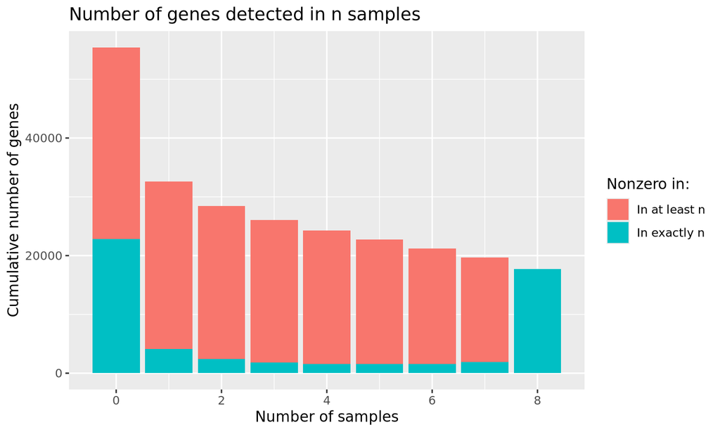

## Filtering by Non-zero Sample Counts

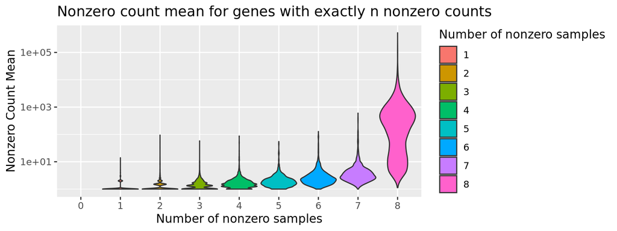

## Mean-variance Relationship

- In counts data, genes with higher mean count also have higher variance
- Mean-variance dependence means these count data are *heteroskedastic*

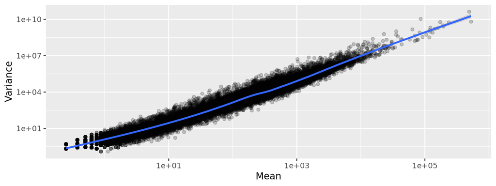

## Filtering For Statistics

- Genes with very few counts do not enable reliable statistical inference
- **There is no biological meaning to any filtering threshold**
- The read counts for a gene depends upon the total number of reads generated
- We cannot use filtering to “remove lowly expressed genes”
- Can only filter out genes that are below the detection threshold afforded by the library size of the dataset

## Count Distributions

- The range of gene expression in a cell varies by orders of magnitude
- Consider the distribution of read counts on a log10 scale from one sample

```r
dplyr::select(filtered_counts, Ad_1) %>%
  filter(Ad_1 > 0) %>% # avoid taking log10(0)
  mutate(`log10(counts)`=log10(Ad_1)) %>%
  ggplot(aes(x=`log10(counts+1)`)) +
  geom_histogram(bins=50) +
  labs(title='log10(counts) distribution for Adult mouse')
```

## Count Distributions

[figure not shown]

## Count Distributions

- Consider distribution for all the samples as a ridgeline plot

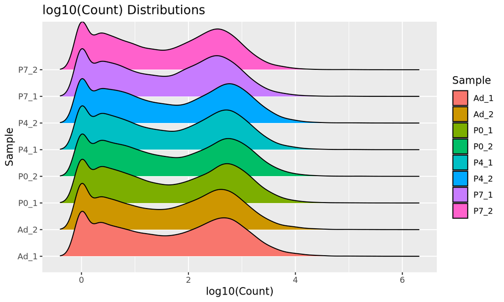

## Count Normalization

- Every sample will have a different number of reads (library size)
- The number of reads that maps to any given gene is dependent upon:
  - the relative abundance of the molecule in the sample
  - the library size of each sample
- The *raw read counts* are not directly comparable between samples
- Counts in each sample must be *normalized* so they are comparable

## Count Normalization

- Count normalization: the process by which the number of raw counts in each sample is scaled by a factor to make multiple samples comparable
- Many strategies have been proposed to do this
- The simplest is: divide every count by some factor of the library size
  - e.g. compute *counts per million reads* or *CPM* normalization

\[ cpm_{s,i} = \frac{c_{s,i}}{l_s} * 10^6 \]

## Counts Per Million

\[ cpm_{s,i} = \frac{c_{s,i}}{l_s} * 10^6 \]

- \(c_{s,i} =\) raw count of gene \(i\) in sample \(s\)
- \(l_s =\) library size for sample \(s\)
- In principle, the proportion of read counts for each gene will be comparable between samples

## CPM Normalization

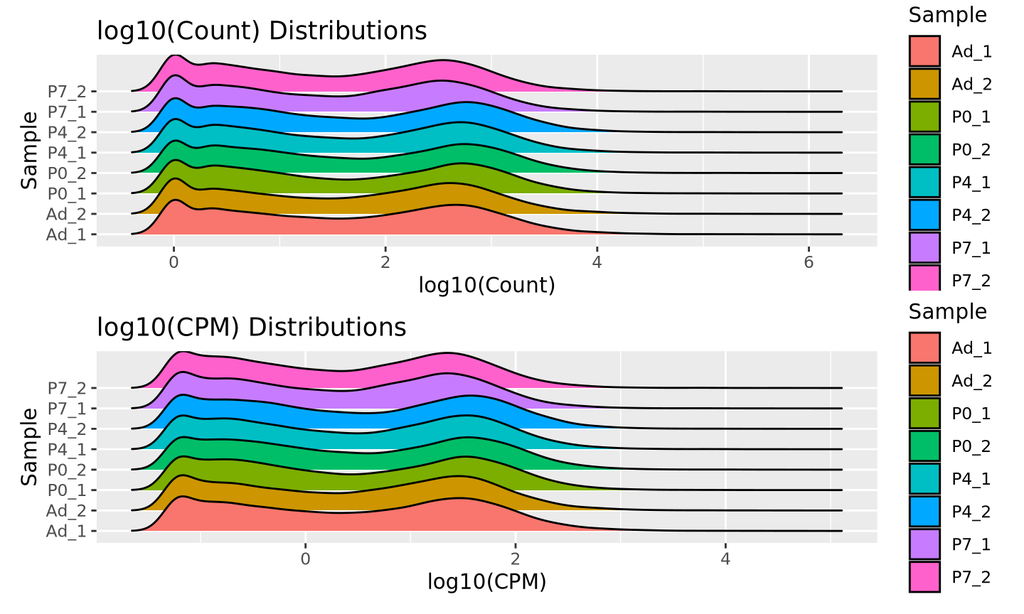

## Library Size Normalization

- CPM is a *library size normalization*
- Library size normalizations are sensitive to extreme outlier genes
  - e.g. if one gene in one sample has abnormally large counts, this can cause other gene counts to be smaller than they truly are
- These outlier counts are common in RNASeq data!
- Normalization method should be robust to these outliers

## DESeq2 Normalization

- DESeq2 bioconductor package introduced a robust normalization method
- Assumes that *most genes are not differentially expressed*
- Uses the median geometric mean computed across all samples to determine the scale factor for each sample
- Currently the *de facto* standard normalization method for well characterized genomes

## DESeq2 Normalization

```r
library(DESeq2)
# DESeq2 requires a counts matrix
# column data (sample information), and a formula
# the counts matrix *must be raw counts*
count_mat <- as.matrix(filtered_counts[-1])

row.names(count_mat) <- filtered_counts$gene

dds <- DESeqDataSetFromMatrix(
  countData=count_mat,
  colData=tibble(sample_name=colnames(filtered_counts[-1])),
  design=~1 # no formula needed, ~1 produces a trivial design matrix
)
```

## DESeq2 Normalization

```r
# compute normalization factors
dds <- estimateSizeFactors(dds)

# extract the normalized counts
deseq_norm_counts <- as_tibble(counts(dds,normalized=TRUE)) %>%
  mutate(gene=filtered_counts$gene) %>%
  relocate(gene) # relocate changes column order
```

## DESeq2 vs CPM

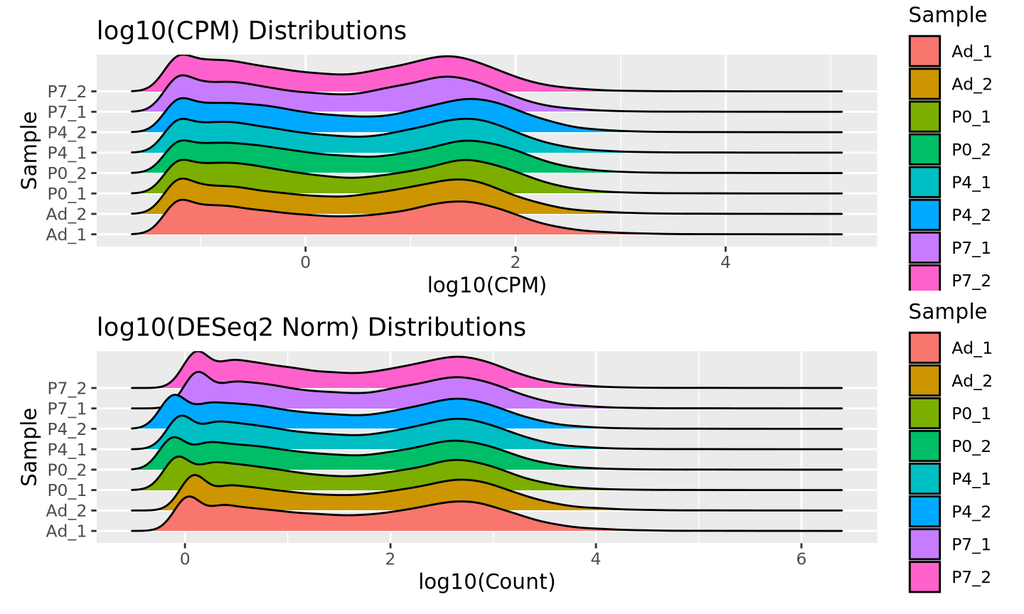

## DESeq2 Considerations

The DESeq2 normalization procedure has two important considerations:

- **The procedure borrows information across all samples.**
- **The procedure does not use genes with any zero counts.**

The CPM normalization procedure does not borrow information across all samples, and therefore is not subject to these considerations.

## Count Transformation

- One way to deal with the non-normality of count data is transform it to follow a normal distribution
- Enables more statistical methods like linear regression to be used
- Count data are roughly *log-normal*, however low and zero counts can be problematic for traditional `log()`
- The DESeq2 package provides the `rlog()` function that performs a regularized logarithmic transformation that avoids these biases

```r
# the dds is the DESeq2 object from earlier
rld <- rlog(dds)
```

## Count Transformation

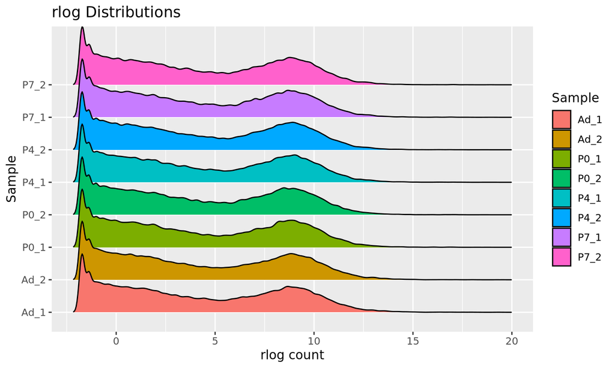

## Differential Expression Analysis

## Differential Expression Analysis

- Goal: identify to what extent gene expression is associated with one or more variables of interest
- Typically analyze whole transcriptome (i.e. 1000s of genes)
- Two required components:
  - an expression matrix (e.g. genes x samples)
  - a *design matrix*

## The Design Matrix

- A design matrix is a numeric matrix that contains
  - the variables we wish to model
  - any covariates or confounders we wish to adjust for
- Encoded in a way that statistical procedures understand
- Construct these matrices from a tibble with the [`model.matrix()` function](https://www.rdocumentation.org/packages/stats/versions/3.6.2/topics/model.matrix)

## Example Metadata

```r
ad_metadata
```

```
## # A tibble: 6 × 8
##   ID    age_at_death condition   tau  abeta   iba1   gfap braak_stage
##   <chr>        <dbl> <fct>     <dbl>  <dbl>  <dbl>  <dbl> <fct>
## 1 A1              73 AD        96548 176324 157501  78139 4
## 2 A2              82 AD        95251      0 147637  79348 4
## 3 A3              82 AD        40287  45365  17655 127131 2
## 4 C1              80 Control   62684  93739 131595 124075 3
## 5 C2              77 Control   63598  69838   7189  35597 3
## 6 C3              72 Control   52951  19444  54673  17221 2
```

## Case vs Control Design

- Model matrix to identify genes that are increased or decreased in people with AD compared with Controls
- The `~ condition` argument is an an R [formula](https://rviews.rstudio.com/2017/02/01/the-r-formula-method-the-good-parts/)

```r
model.matrix(~ condition, data=ad_metadata)
```

## Case vs Control Design

```r
model.matrix(~ condition, data=ad_metadata)
```

```
##   (Intercept) conditionAD
## 1           1           1
## 2           1           1
## 3           1           1
## 4           1           0
## 5           1           0
## 6           1           0
## attr(,"assign")
## [1] 0 1
## attr(,"contrasts")
## attr(,"contrasts")$condition
## [1] "contr.treatment"
```

## Formulas in R

The general format of a formula is as follows:

```r
# portions in [] are optional
[<outcome variable>] ~ <predictor 1> [+ <predictor 2>]...

# examples

# model Gene 3 expression as a function of disease status
`Gene 3` ~ condition

# model the amount of tau pathology as a function of abeta pathology,
# adjusting for age at death
tau ~ age_at_death + abeta

# can create a model without an outcome variable
~ age_at_death + condition
```

## More Complex Designs

- Can include other variables in model to adjust for covariates or test other contrasts
- e.g. adjust out the effect of age by including `age_at_death` as a covariate in the model:

```r
model.matrix(~ age_at_death + condition, data=ad_metadata)
```

## More Complex Designs

```r
model.matrix(~ age_at_death + condition, data=ad_metadata)
```

```
##   (Intercept) age_at_death conditionAD
## 1           1           73           1
## 2           1           82           1
## 3           1           82           1
## 4           1           80           0
## 5           1           77           0
## 6           1           72           0
## attr(,"assign")
## [1] 0 1 2
## attr(,"contrasts")
## attr(,"contrasts")$condition
## [1] "contr.treatment"
```

## Differential Expression: Microarrays (limma)

## Differential Expression: Microarrays (limma)

- [limma](https://bioconductor.org/packages/release/bioc/html/limma.html): `li`near `m`odels of `mi`croarrays
- Designed for analyzing microarray gene expression data
- One of the [top most downloaded](https://bioconductor.org/packages/stats/) Bioconductor packages
- Supports arbitrarily complex experimental designs while maintaining strong statistical power
- Can perform reliable inference even with small sample sizes

## limma Example Setup

- limma requires:
  - `ExpressionSet` or `SummarizedExperiment` container
  - a design matrix

```r
ad_se  <- SummarizedExperiment(
  assays=list(intensities=intensities),
  colData=ad_metadata,
  rowData=rownames(intensities)
)

# design matrix for AD vs control, adjusting for age at death
ad_vs_control_model <- model.matrix(
  ~ age_at_death + condition,
  data=ad_metadata
)
```

## limma Example: fit model

```r
# now run limma
# first fit all genes with the model
fit <- limma::lmFit(
  assays(se)$intensities,
  ad_vs_control_model
)

# now better control fit errors with the empirical Bayes method
fit <- limma::eBayes(fit)
```

## limma Results

- Look at top results using `limma::topTable()` function:

```r
# the coefficient name conditionAD is the column name in the design matrix
topTable(fit, coef="conditionAD", adjust="BH", number=5)
```

```
##                  logFC  AveExpr         t      P.Value adj.P.Val         B
## 206354_at   -2.7507429 5.669691 -5.349105 3.436185e-05 0.9992944 -2.387433
## 234942_s_at  0.9906708 8.397425  5.206286 4.726372e-05 0.9992944 -2.447456
## 243618_s_at -0.6879431 7.148455 -4.864695 1.020980e-04 0.9992944 -2.598600
## 223703_at    0.8693657 6.154392  4.745033 1.340200e-04 0.9992944 -2.654092
## 244391_at   -0.5251423 5.532712 -4.691482 1.514215e-04 0.9992944 -2.679354
```

## Differential Expression: RNASeq

## Differential Expression: RNASeq

- Normalized read counts are suitable for differential expression
- Counts matrix created by concatenating read counts for all genes rows are genes or transcripts and columns are samples
- Read counts not normally distributed, requires statistical approach that either
  1. Models counts explicitly
  2. Transform counts to be normally distributed, use common statistical methods

## Modeling Count Data

- Poisson distribution: expresses probability that a given number of events occur in a fixed period, e.g. time, space, distance, area, volume
- Can model number of reads aligning to a given genome position/locus
- Whole Genome Sequencing (WGS) data are modeled this way

## Poisson Distribution

\[ f(k;\lambda) = \mathtt{Pr}(X=k) = \frac{\lambda^k e^{-\lambda}}{k!} \]

- \(\lambda\) is the average number of events observed in each period

\[ \lambda = \mathtt{E}(X) = \mathtt{Var}(X) \]

- In Poisson, the mean and variance are assumed to be equal

## WGS Read Depth

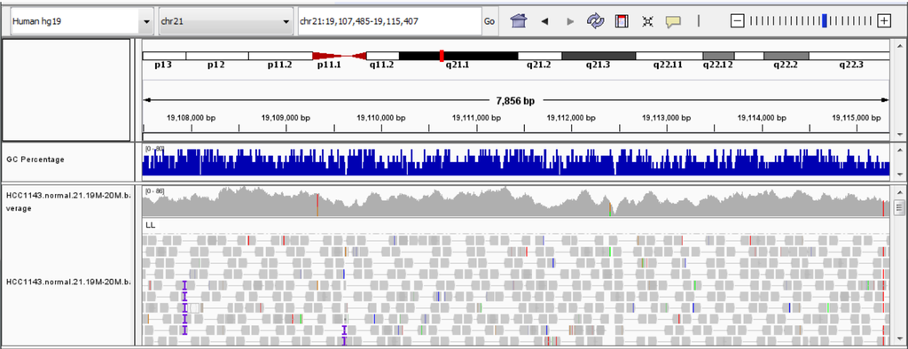

## WGS Read Depth Distribution

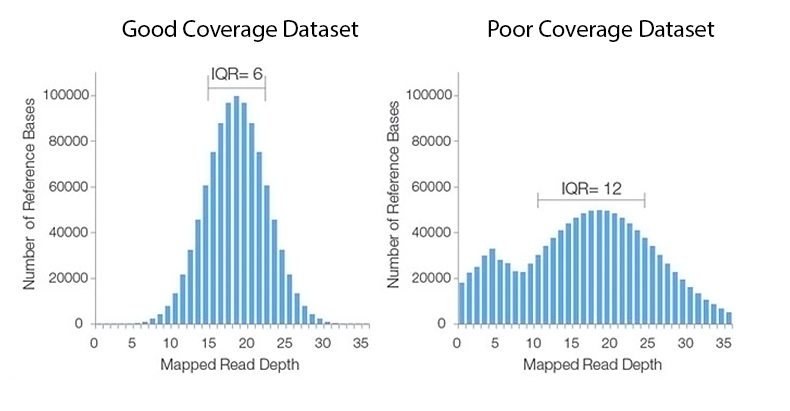